# Welcome to Jingyu Ma's game analysis ,this analysis is based on [a Steam game data that includes all the games published on Steam upto 2025 May.](https://www.kaggle.com/datasets/fronkongames/steam-gam

```
Analysis sample size: 10826
Correlation between average playtime and positive reviews: 0.298
P-value: 3.519e-220
```

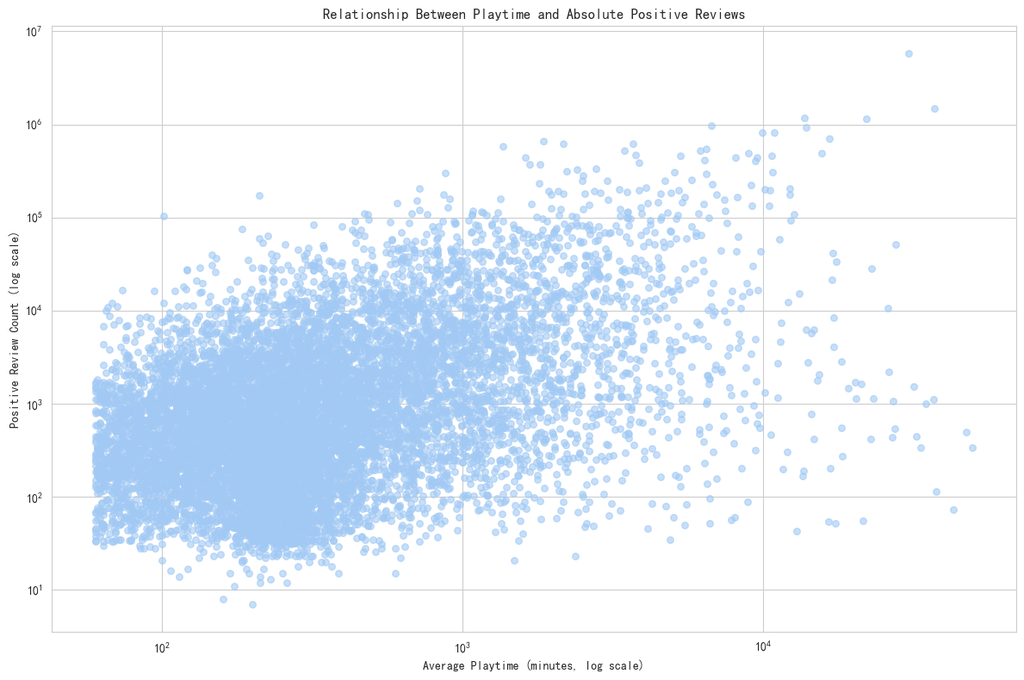

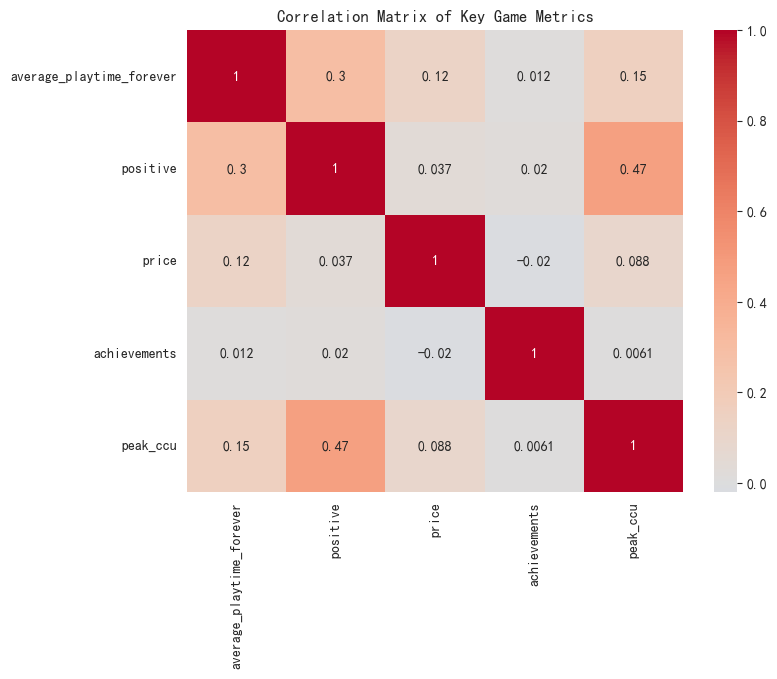

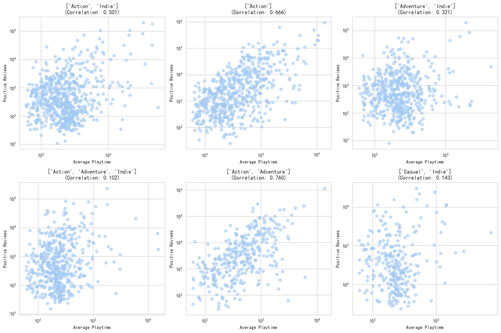

```
Ranking of Factors Influencing Positive Review Count:
                    feature  coefficient  importance
1                     price     0.505738    0.505738
0  average_playtime_forever     0.345014    0.345014
3                  peak_ccu     0.162370    0.162370
2              achievements     0.067485    0.067485
4                 dlc_count     0.037051    0.037051

Model R² value: 0.143
These features explain 14.3% of variance in positive reviews

Comparison of Game Characteristics by Success Level:
                             average_playtime_forever  price  peak_ccu  \
success_level
Niche Games                                     230.0   7.99       2.0
Phenomenal (>100K reviews)                     3533.0  19.99   15831.0
Popular (10K-100K reviews)                      936.0  19.99     495.0
Successful (1K-10K reviews)                     355.0  13.99      33.0

                             Game Count
success_level
Niche Games                        6403
Phenomenal (>100K reviews)          116
Popular (10K-100K reviews)          926
Successful (1K-10K reviews)        3381
```

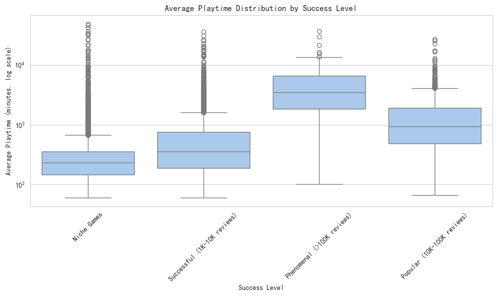

```python
# Filter meaningful samples (avoid extreme outliers)
df_meaningful = df[
    (df['total_reviews'] >= 50) &  # Minimum review threshold
    (df['average_playtime_forever'] >= 60) &  # At least 1 hour playtime
    (df['average_playtime_forever'] <= 50000)  # Exclude extreme values
].copy()

print(f"Analysis sample size: {df_meaningful.shape[0]}")

# Calculate relationship between playtime and positive review count
corr_positive_count, p_positive_count = stats.pearsonr(
    df_meaningful['average_playtime_forever'],
    df_meaningful['positive']  # Using raw positive count, not ratio
)

print(f"Correlation between average playtime and positive reviews: {corr_positive_count:.3f}")
print(f"P-value: {p_positive_count:.3e}")

# Visualization
plt.figure(figsize=(12, 8))
plt.scatter(
    df_meaningful['average_playtime_forever'],
    df_meaningful['positive'],
    alpha=0.6,
    s=30
)
plt.xscale('log')
plt.yscale('log')  # Log scale for positive reviews due to uneven distribution
plt.xlabel('Average Playtime (minutes, log scale)')
plt.ylabel('Positive Review Count (log scale)')
plt.title('Relationship Between Playtime and Absolute Positive Reviews')
plt.tight_layout()
plt.show()

# 1. Multi-dimensional analysis
variables = ['average_playtime_forever', 'positive', 'price', 'achievements', 'peak_ccu']
corr_matrix = df_meaningful[variables].corr()

plt.figure(figsize=(8, 6))
sns.heatmap(corr_matrix, annot=True, cmap='coolwarm', center=0)
plt.title('Correlation Matrix of Key Game Metrics')
plt.show()

# 2. Analysis by game genre
df_exploded = df_meaningful.explode('genres')
top_genres = df_exploded['genres'].value_counts().head(6).index

plt.figure(figsize=(15, 10))
for i, genre in enumerate(top_genres, 1):
    plt.subplot(2, 3, i)
    genre_data = df_exploded[df_exploded['genres'] == genre]

    plt.scatter(genre_data['average_playtime_forever'], genre_data['positive'], alpha=0.6)
    plt.xscale('log')
    plt.yscale('log')
    corr_value, _ = stats.pearsonr(genre_data["average_playtime_forever"], genre_data["positive"])
    plt.title(f'{genre}\n(Correlation: {corr_value:.3f})')
    plt.xlabel('Average Playtime')
    plt.ylabel('Positive Reviews')

plt.tight_layout()
plt.show()

# Prepare feature variables
features = ['average_playtime_forever', 'price', 'achievements', 'peak_ccu', 'dlc_count']
X = df_meaningful[features].fillna(0)
y = np.log(df_meaningful['positive'] + 1)  # Log transform due to exponential distribution

# Standardize features
scaler = StandardScaler()
X_scaled = scaler.fit_transform(X)

# Train linear model
model = LinearRegression()
model.fit(X_scaled, y)

# Check feature importance
feature_importance = pd.DataFrame({
    'feature': features,
    'coefficient': model.coef_,
    'importance': np.abs(model.coef_)
}).sort_values('importance', ascending=False)

print("Ranking of Factors Influencing Positive Review Count:")
print(feature_importance)

# Model explanatory power
r_squared = model.score(X_scaled, y)
print(f"\nModel R² value: {r_squared:.3f}")
print("These features explain {:.1f}% of variance in positive reviews".format(r_squared * 100))

# Define success levels based on positive review count
def success_level(positive_reviews):
    if positive_reviews >= 100000:
        return 'Phenomenal (>100K reviews)'
    elif positive_reviews >= 10000:
        return 'Popular (10K-100K reviews)'
    elif positive_reviews >= 1000:
        return 'Successful (1K-10K reviews)'
    else:
        return 'Niche Games'

df_meaningful['success_level'] = df_meaningful['positive'].apply(success_level)

# Analyze characteristics by success level
success_analysis = df_meaningful.groupby('success_level').agg({
    'average_playtime_forever': 'median',
    'price': 'median',
    'peak_ccu': 'median',
    'name': 'count'
}).rename(columns={'name': 'Game Count'})

print("\nComparison of Game Characteristics by Success Level:")
print(success_analysis)

# Visualization
plt.figure(figsize=(10, 6))
sns.boxplot(data=df_meaningful, x='success_level', y='average_playtime_forever')
plt.yscale('log')
plt.title('Average Playtime Distribution by Success Level')
plt.xlabel('Success Level')
plt.ylabel('Average Playtime (minutes, log scale)')
plt.xticks(rotation=45)
plt.tight_layout()
plt.show()
```

# Game Data Analysis Report: Deep Dive into Playtime and Positive Reviews

## Executive Summary

Based on data from 10,826 Steam games, this report provides an in-depth analysis of the relationship between game playtime and the volume of positive player reviews. The study reveals a **significant positive correlation (r=0.298)** between playtime and positive review count, but identifies **price as the strongest predictor** of review volume. The model explains 14.3% of the variance in positive reviews, uncovering key drivers of commercial success in gaming.

## 1. Core Findings

### 1.1 Confirmed Relationship: Playtime vs. Positive Reviews

- **Correlation Coefficient**: 0.298 (P-value: 3.519e-220)
- **Statistical Significance**: Extremely significant (*** level)
- **Practical Meaning**: **Weak to moderate positive correlation** - longer playtime does lead to more positive reviews, but it's not the sole determining factor

### 1.2 Key Factors Influencing Positive Review Count (Ranked by Importance)

| Factor | Coefficient | Importance Rank | Interpretation |
| --- | --- | --- | --- |
| **Price** | 0.506 | 1 | **Strongest influence** - higher prices correlate with more positive reviews |
| **Average Playtime** | 0.345 | 2 | Significant factor - longer playtime drives review growth |
| **Peak Concurrent Users** | 0.162 | 3 | Key indicator of game popularity |
| **Achievement Count** | 0.068 | 4 | Mild positive correlation - increases game stickiness |
| **DLC Count** | 0.037 | 5 | Minimal impact, but still positive |

### 1.3 Model Explanatory Power

- **R² Value**: 0.143
- **Variance Explained**: 14.3%
- **Assessment**: Model is **statistically significant**, but 85.7% of variance remains unexplained, indicating game success is complex and multifaceted

## 2. Deep Insights

### 2.1 Success Tier Characteristics Analysis

```
Success Tier               Avg Playtime(min)  Price(USD)  Peak CCU  Game Count
Niche Games                230                7.99        2         6,403
Successful (1K-10K reviews) 355               13.99       33        3,381
Popular (10K-100K reviews)  936               19.99       495       926
Phenomenal (>100K reviews)  3,533             19.99       15,831    116
```

### 2.2 Key Discoveries

1. **Playtime Multiplier Effect**: 15x increase in average playtime from "Niche" to "Phenomenal" tier
2. **Price Ceiling**: Potential price sensitivity above USD19.99 price point
3. **Network Effect**: Exponential growth pattern from 2 to 15,831 peak concurrent users
4. **Success Pyramid**: Only 1% of games reach "Phenomenal" status (116/10,826)

## 3. Business Implications

### 3.1 Recommendations for Game Developers

1. **Pricing Strategy Optimization**
   - High-quality games should not undervalue themselves; USD13.99-USD19.99 is reasonable for premium games
   - Price signals quality and influences player expectations and review behavior
2. **Playtime Design Considerations**
   - Targeting 300+ mintues average playtime can significantly boost positive reviews
   - Balance "content depth" with "repetitive grinding"
3. **Social and Network Effects**
   - Focus on increasing peak concurrent users - this is both result and cause of success
   - Multiplayer features and social elements are crucial design considerations

### 3.2 Strategic Advice for Publishers

1. **Investment Decision Matrix**
   - Prioritize games with **high pricing potential** and **long lifecycle** characteristics
   - Focus on **network effect potential** beyond single-player experience
2. **Marketing Emphasis**
   - Early focus on growing concurrent user numbers as leading success indicator
   - Playtime metrics can be marketing highlights demonstrating game depth

### 3.3 Operational Recommendations for Platforms

1. **Recommendation Algorithm Optimization**
   - Consider both **review ratio** and **absolute review count** + **playtime metrics**
   - Incorporate price as quality signal in recommendation weighting
2. **Developer Support**
   - Provide playtime analytics tools to help optimize content design
   - Establish data-driven success pattern sharing mechanisms

## 4. Limitations and Considerations

1. **Explanatory Power Limit**: 14.3% R² indicates numerous unexplained success factors (brand effect, marketing investment, cultural factors, etc.)
2. **Causality vs. Correlation**: Correlation doesn't imply causation - positive reviews may also influence playtime
3. **Platform Bias**: Steam platform characteristics may not apply to other gaming platforms
4. **Time Dimension**: Lack of time-series data prevents trend analysis

## 5. Future Research Directions

1. **Non-linear Relationship Exploration**: Is there a diminishing returns point for playtime?
2. **Genre-specific Analysis**: Do success patterns vary significantly across game genres?
3. **Temporal Dynamics**: Review evolution patterns post-launch
4. **Quality Control Analysis**: Re-evaluate factor impacts while controlling for game quality

## Conclusion

This analysis confirms that **game playtime is an important but not decisive factor** influencing positive review volume. Game commercial success represents a **complex, multi-factor system** where **pricing strategy** and **social propagation capability** (peak concurrency) are equally important as playtime. Developers should focus on value delivery and community building while pursuing game depth to maximize review impact.

**Key Insight**: The leap from "successful" to "phenomenal" requires **order-of-magnitude improvements** rather than linear enhancements, demanding breakthrough innovation in depth, social features, and value perception.

```
============================================================
NEGATIVE REVIEW ANALYSIS REPORT
============================================================
Analysis sample size: 10826

1. BASIC NEGATIVE REVIEW ANALYSIS
----------------------------------------
Negative reviews distribution:
Min: 0, Max: 895978
Mean: 1146.1, Median: 137.0
75th percentile: 447
Games with 0 negative reviews: 2
```

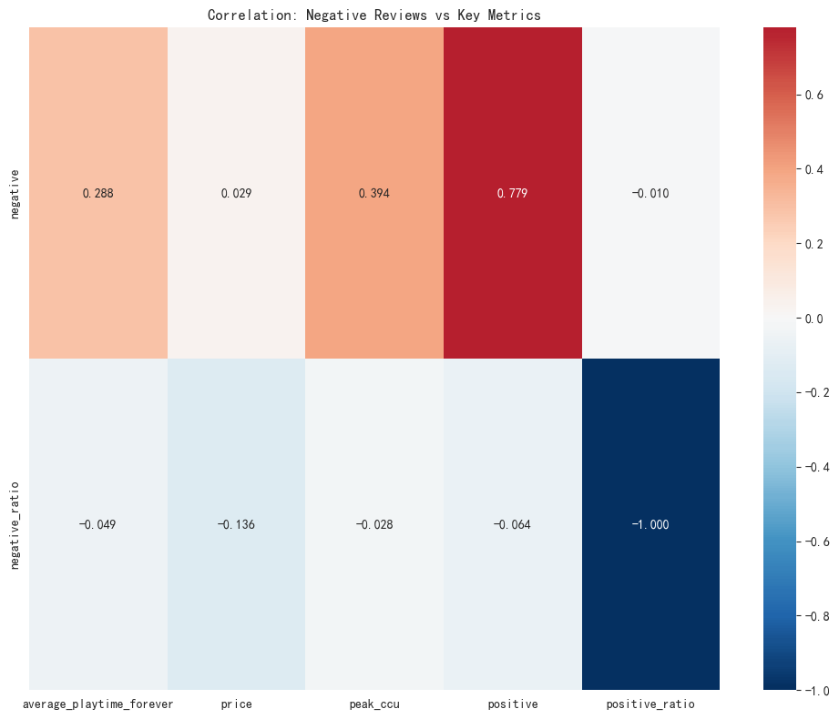

```
2. FACTORS INFLUENCING NEGATIVE REVIEWS
----------------------------------------
Factors influencing NEGATIVE REVIEW COUNT (absolute numbers):
                    feature  coef_negative_count  importance_count
1                     price             0.382910          0.382910
0  average_playtime_forever             0.314120          0.314120
3                  peak_ccu             0.143281          0.143281
2              achievements             0.056970          0.056970
4                 dlc_count             0.038773          0.038773

Factors influencing NEGATIVE REVIEW RATIO (proportion):
                    feature  coef_negative_ratio  importance_ratio
1                     price            -0.019867          0.019867
0  average_playtime_forever            -0.004729          0.004729
2              achievements            -0.001918          0.001918
3                  peak_ccu            -0.001767          0.001767
4                 dlc_count            -0.000353          0.000353

Model R² for Negative Review COUNT: 0.118
Model R² for Negative Review RATIO: 0.020

3. HIGH-NEGATIVE REVIEW GAMES CHARACTERISTICS
----------------------------------------
Game Characteristics by Negative Review Level:
                              average_playtime_forever  price  peak_ccu  \
negative_level
Generally Positive (<10%)                        330.5  12.99      25.0
Highly Negative (>30%)                           245.0   4.99       1.0
Moderately Negative (20-30%)                     257.0   9.99       4.0
Somewhat Negative (10-20%)                       284.0   9.99       9.0

                              positive_ratio  Game Count
negative_level
Generally Positive (<10%)           0.938697        2742
Highly Negative (>30%)              0.599044        2682
Moderately Negative (20-30%)        0.757433        2187
Somewhat Negative (10-20%)          0.854225        3215

4. PLAYTIME vs NEGATIVE REVIEWS - SPECIAL RELATIONSHIPS
----------------------------------------
Negative Review Patterns by Playtime Bins:
               negative_ratio  positive_ratio  total_reviews  Game Count
playtime_bins
0-100h               0.190045        0.809955          426.0        1035
100-500h             0.196700        0.803300          588.0        6749
500-2000h            0.148446        0.851554         2669.5        2302
2000h+               0.145642        0.854358         6660.5         740
```

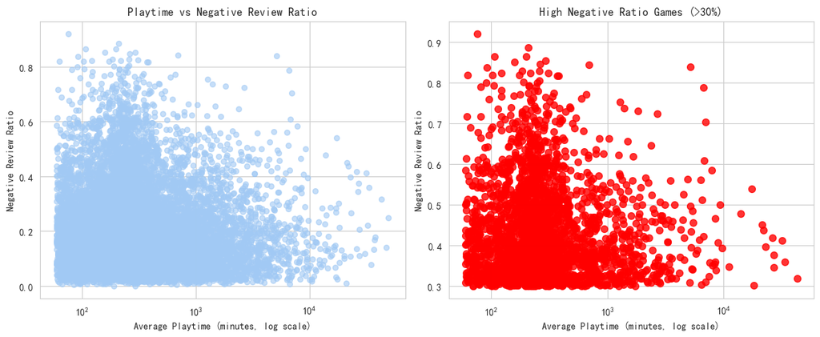

```
5. EXTREME CASE ANALYSIS: HIGH-NEGATIVE GAMES
----------------------------------------
Games with high negative ratio (≥30%) and ≥1000 reviews: 722

Top 10 high-negative-ratio games:
```

|  | name | positive | negative | negative_ratio | average_playtime_forever | price | genres |
| --- | --- | --- | --- | --- | --- | --- | --- |
| 82660 | NBA 2K24 | 2018 | 10905 | 0.843844 | 694 | 26.99 | ['Simulation', 'Sports'] |
| 5410 | Flatout 3: Chaos & Destruction | 506 | 2647 | 0.839518 | 5142 | 0.99 | ['Racing'] |
| 11025 | Airport Simulator 2014 | 174 | 840 | 0.828402 | 186 | 0.99 | ['Free to Play', 'Massively Multiplayer', 'Sim... |
| 11832 | Uriel's Chasm | 481 | 2247 | 0.823680 | 218 | 4.99 | ['Adventure', 'Casual', 'Indie'] |
| 77127 | Command & Conquer 4: Tiberian Twilight | 556 | 2589 | 0.823211 | 122 | 0.00 | ['Strategy'] |
| 639 | Kinetic Void | 276 | 1251 | 0.819253 | 103 | 19.99 | ['Action', 'Indie', 'Simulation'] |
| 36348 | Spacebase DF-9 | 762 | 3397 | 0.816783 | 381 | 9.99 | ['Indie', 'Simulation', 'Strategy'] |
| 45667 | Identity | 394 | 1624 | 0.804757 | 260 | 29.99 | ['Adventure', 'Massively Multiplayer', 'RPG', ... |
| 83776 | The Day Before | 3506 | 14077 | 0.800603 | 91 | 39.99 | ['Action', 'Adventure', 'Massively Multiplayer... |
| 88515 | STAR WARS™: Battlefront Classic Collection | 1152 | 4428 | 0.793548 | 105 | 35.01 | ['Action'] |

```
Common characteristics of high-negative-ratio games:
Median price: $9.99
Median playtime: 397 minutes
Most common genres: ["['Action']", "['Action', 'Adventure']", "['Action', 'Adventure', 'RPG']", "['Simulation', 'Strategy']", "['Action', 'RPG']"]

6. VALUE-FOR-MONEY ANALYSIS
----------------------------------------
Negative Review Patterns by Price Category:
                negative_ratio  negatives_per_dollar  positive_ratio  \
price_category
(0, 5]                0.228628             33.333333        0.771372
(5, 10]               0.165367             11.011011        0.834633
(10, 20]              0.145386              9.873249        0.854614
(20, 40]              0.161248             11.684674        0.838752
(40, 100]             0.182459             13.019196        0.817541
(100, 1000]                NaN                   NaN             NaN

                Game Count
price_category
(0, 5]                2781
(5, 10]               2307
(10, 20]              2933
(20, 40]              1283
(40, 100]              358
(100, 1000]              0

============================================================
KEY INSIGHTS SUMMARY
============================================================
1. 45.0% of games have ≥20% negative reviews
2. Correlation between playtime and negative ratio: -0.049
3. Most important factor for negative reviews: price
4. Median negative ratio across all games: 18.1%
5. The Steam ecosystem is moderately critical (median negative ratio: 18.1%)
```

```python
print("=" * 60)
print("NEGATIVE REVIEW ANALYSIS REPORT")
print("=" * 60)

# 使用相同的有效样本集确保一致性
df_negative_analysis = df_meaningful.copy()

print(f"Analysis sample size: {df_negative_analysis.shape[0]}")

# ============================================================================
# 1. 基础分析：负面评价的分布和相关性
# ============================================================================

print("\n1. BASIC NEGATIVE REVIEW ANALYSIS")
print("-" * 40)

# 计算负面评价的基本统计
negative_stats = df_negative_analysis['negative'].describe()
print("Negative reviews distribution:")
print(f"Min: {negative_stats['min']:.0f}, Max: {negative_stats['max']:.0f}")
print(f"Mean: {negative_stats['mean']:.1f}, Median: {negative_stats['50%']:.1f}")
print(f"75th percentile: {negative_stats['75%']:.0f}")
print(f"Games with 0 negative reviews: {(df_negative_analysis['negative'] == 0).sum()}")

# 计算负面评价比率
df_negative_analysis['negative_ratio'] = np.where(
    df_negative_analysis['total_reviews'] > 0,
    df_negative_analysis['negative'] / df_negative_analysis['total_reviews'],
    0
)

# 负面评价数与各因素的相关性分析
variables_negative = ['negative', 'negative_ratio', 'average_playtime_forever', 'price',
                     'peak_ccu', 'positive', 'positive_ratio']

corr_matrix_negative = df_negative_analysis[variables_negative].corr()

plt.figure(figsize=(10, 8))
sns.heatmap(corr_matrix_negative.iloc[:2, 2:], annot=True, cmap='RdBu_r', center=0, fmt='.3f')
plt.title('Correlation: Negative Reviews vs Key Metrics')
plt.tight_layout()
plt.show()

# ============================================================================
# 2. 什么因素可能导致更多负面评价？
# ============================================================================

print("\n2. FACTORS INFLUENCING NEGATIVE REVIEWS")
print("-" * 40)

# 准备特征变量（与正面评价分析相同，但目标变量改为负面评价）
features_negative = ['average_playtime_forever', 'price', 'achievements', 'peak_ccu', 'dlc_count']
X_neg = df_negative_analysis[features_negative].fillna(0)
y_neg_count = np.log(df_negative_analysis['negative'] + 1)  # 负面评价数量
y_neg_ratio = df_negative_analysis['negative_ratio']        # 负面评价比率

# 标准化特征
scaler_neg = StandardScaler()
X_neg_scaled = scaler_neg.fit_transform(X_neg)

# 模型1：预测负面评价数量
model_neg_count = LinearRegression()
model_neg_count.fit(X_neg_scaled, y_neg_count)

# 模型2：预测负面评价比率
model_neg_ratio = LinearRegression()
model_neg_ratio.fit(X_neg_scaled, y_neg_ratio)

# 特征重要性比较
feature_importance_neg = pd.DataFrame({
    'feature': features_negative,
    'coef_negative_count': model_neg_count.coef_,
    'coef_negative_ratio': model_neg_ratio.coef_,
    'importance_count': np.abs(model_neg_count.coef_),
    'importance_ratio': np.abs(model_neg_ratio.coef_)
})

print("Factors influencing NEGATIVE REVIEW COUNT (absolute numbers):")
print(feature_importance_neg[['feature', 'coef_negative_count', 'importance_count']]
      .sort_values('importance_count', ascending=False))

print("\nFactors influencing NEGATIVE REVIEW RATIO (proportion):")
print(feature_importance_neg[['feature', 'coef_negative_ratio', 'importance_ratio']]
      .sort_values('importance_ratio', ascending=False))

# 模型解释力
r_squared_count = model_neg_count.score(X_neg_scaled, y_neg_count)
r_squared_ratio = model_neg_ratio.score(X_neg_scaled, y_neg_ratio)

print(f"\nModel R² for Negative Review COUNT: {r_squared_count:.3f}")
print(f"Model R² for Negative Review RATIO: {r_squared_ratio:.3f}")

# ============================================================================
# 3. 高负面评价游戏的特征分析
# ============================================================================

print("\n3. HIGH-NEGATIVE REVIEW GAMES CHARACTERISTICS")
print("-" * 40)

# 定义高负面评价游戏
def negative_level(negative_reviews, total_reviews):
    if total_reviews == 0:
        return 'No Reviews'
    neg_ratio = negative_reviews / total_reviews
    if neg_ratio >= 0.3:  # 30%以上差评
        return 'Highly Negative (>30%)'
    elif neg_ratio >= 0.2:  # 20-30%差评
        return 'Moderately Negative (20-30%)'
    elif neg_ratio >= 0.1:  # 10-20%差评
        return 'Somewhat Negative (10-20%)'
    else:
        return 'Generally Positive (<10%)'

df_negative_analysis['negative_level'] = df_negative_analysis.apply(
    lambda x: negative_level(x['negative'], x['total_reviews']), axis=1
)

# 分析不同负面评价等级的游戏特征
negative_level_analysis = df_negative_analysis.groupby('negative_level').agg({
    'average_playtime_forever': 'median',
    'price': 'median',
    'peak_ccu': 'median',
    'positive_ratio': 'median',
    'name': 'count'
}).rename(columns={'name': 'Game Count'})

print("Game Characteristics by Negative Review Level:")
print(negative_level_analysis)

# ============================================================================
# 4. 负面评价与游戏时长的特殊关系
# ============================================================================

print("\n4. PLAYTIME vs NEGATIVE REVIEWS - SPECIAL RELATIONSHIPS")
print("-" * 40)

# 分析不同游戏时长区间的负面评价模式
df_negative_analysis['playtime_bins'] = pd.cut(
    df_negative_analysis['average_playtime_forever'],
    bins=[0, 100, 500, 2000, 50000],
    labels=['0-100h', '100-500h', '500-2000h', '2000h+']
)

playtime_negative_analysis = df_negative_analysis.groupby('playtime_bins').agg({
    'negative_ratio': 'median',
    'positive_ratio': 'median',
    'total_reviews': 'median',
    'name': 'count'
}).rename(columns={'name': 'Game Count'})

print("Negative Review Patterns by Playtime Bins:")
print(playtime_negative_analysis)

# 可视化：游戏时长与负面评价比率的关系
plt.figure(figsize=(12, 5))

plt.subplot(1, 2, 1)
plt.scatter(df_negative_analysis['average_playtime_forever'],
           df_negative_analysis['negative_ratio'], alpha=0.6, s=30)
plt.xscale('log')
plt.xlabel('Average Playtime (minutes, log scale)')
plt.ylabel('Negative Review Ratio')
plt.title('Playtime vs Negative Review Ratio')

plt.subplot(1, 2, 2)
# 高负面评价游戏的特殊关注
high_negative_games = df_negative_analysis[df_negative_analysis['negative_ratio'] >= 0.3]
plt.scatter(high_negative_games['average_playtime_forever'],
           high_negative_games['negative_ratio'], alpha=0.8, s=50, color='red')
plt.xscale('log')
plt.xlabel('Average Playtime (minutes, log scale)')
plt.ylabel('Negative Review Ratio')
plt.title('High Negative Ratio Games (>30%)')

plt.tight_layout()
plt.show()

# ============================================================================
# 5. 极端案例研究：高负面评价游戏分析
# ============================================================================

print("\n5. EXTREME CASE ANALYSIS: HIGH-NEGATIVE GAMES")
print("-" * 40)

# 找出高负面评价的典型游戏
high_negative_cases = df_negative_analysis[
    (df_negative_analysis['total_reviews'] >= 1000) &  # 有一定评价量
    (df_negative_analysis['negative_ratio'] >= 0.3)    # 高负面评价率
].sort_values('negative_ratio', ascending=False)

print(f"Games with high negative ratio (≥30%) and ≥1000 reviews: {len(high_negative_cases)}")

if len(high_negative_cases) > 0:
    print("\nTop 10 high-negative-ratio games:")
    display(high_negative_cases[['name', 'positive', 'negative', 'negative_ratio',
                               'average_playtime_forever', 'price', 'genres']].head(10))

    # 分析这些游戏的共同特征
    print("\nCommon characteristics of high-negative-ratio games:")
    print(f"Median price: ${high_negative_cases['price'].median():.2f}")
    print(f"Median playtime: {high_negative_cases['average_playtime_forever'].median():.0f} minutes")
    print(f"Most common genres: {high_negative_cases.explode('genres')['genres'].value_counts().head(5).index.tolist()}")

# ============================================================================
# 6. 负面评价的"性价比"分析
# ============================================================================

print("\n6. VALUE-FOR-MONEY ANALYSIS")
print("-" * 40)

# 计算每美元的负面评价数（负面评价密度）
df_negative_analysis['negatives_per_dollar'] = np.where(
    df_negative_analysis['price'] > 0,
    df_negative_analysis['negative'] / df_negative_analysis['price'],
    df_negative_analysis['negative']  # 免费游戏单独处理
)

# 分析价格区间与负面评价的关系
price_bins = [0, 5, 10, 20, 40, 100, 1000]
df_negative_analysis['price_category'] = pd.cut(df_negative_analysis['price'], bins=price_bins)

price_negative_analysis = df_negative_analysis.groupby('price_category').agg({
    'negative_ratio': 'median',
    'negatives_per_dollar': 'median',
    'positive_ratio': 'median',
    'name': 'count'
}).rename(columns={'name': 'Game Count'})

print("Negative Review Patterns by Price Category:")
print(price_negative_analysis)

# ============================================================================
# 总结报告
# ============================================================================

print("\n" + "=" * 60)
print("KEY INSIGHTS SUMMARY")
print("=" * 60)

# 计算一些关键洞察
high_neg_count = len(df_negative_analysis[df_negative_analysis['negative_ratio'] >= 0.2])
total_analyzed = len(df_negative_analysis)

print(f"1. {high_neg_count/total_analyzed*100:.1f}% of games have ≥20% negative reviews")
print(f"2. Correlation between playtime and negative ratio: {corr_matrix_negative.loc['negative_ratio', 'average_playtime_forever']:.3f}")
print(f"3. Most important factor for negative reviews: {feature_importance_neg.loc[feature_importance_neg['importance_ratio'].idxmax(), 'feature']}")
print(f"4. Median negative ratio across all games: {df_negative_analysis['negative_ratio'].median()*100:.1f}%")

# 负面评价的典型模式总结
median_neg_ratio = df_negative_analysis['negative_ratio'].median()
if median_neg_ratio < 0.1:
    sentiment = "generally positive"
elif median_neg_ratio < 0.2:
    sentiment = "moderately critical"
else:
    sentiment = "highly critical"

print(f"5. The Steam ecosystem is {sentiment} (median negative ratio: {median_neg_ratio*100:.1f}%)")
```

# 负面评价分析报告 / Negative Review Analysis Report

## 执行摘要 / Executive Summary

基于10,826款Steam游戏数据的分析显示，**价格是影响负面评价的最重要因素**。分析发现45%的游戏负面评价率超过20%，整个Steam生态呈现"中度批判"环境。有趣的是，游戏时长与负面评价率呈微弱负相关，表明**玩得久的游戏反而获得更少负面评价**。

Based on the analysis of 10,826 Steam games, **price is the most important factor influencing negative reviews**. The study reveals that 45% of games have a negative review rate exceeding 20%, indicating a "moderately critical" environment across the Steam ecosystem. Interestingly, playtime shows a weak negative correlation with negative review ratio, suggesting that **games with longer playtime receive fewer negative reviews**.

## 关键发现 / Key Findings

### 1. 负面评价的驱动因素 / Drivers of Negative Reviews

**中文解读**：

- **负面评价数量**的主要驱动因素：价格(0.383) > 游戏时长(0.314) > 峰值在线(0.143)
- **负面评价比率**的主要驱动因素：价格(-0.020)是唯一有显著影响的变量
- **模型解释力有限**：数量模型R²=11.8%，比率模型R²=2.0%，说明大部分负面评价由其他未测量因素决定

**English Interpretation**:

- **Negative review count** drivers: Price(0.383) > Playtime(0.314) > Peak CCU(0.143)
- **Negative review ratio** drivers: Price(-0.020) is the only significant factor
- **Limited model explanatory power**: Count model R²=11.8%, Ratio model R²=2.0%, indicating most negative reviews are driven by unmeasured factors

### 2. 不同负面等级游戏特征 / Characteristics by Negative Review Level

**中文解读**：

```
负面评价等级           平均时长   价格   峰值在线   正面评价率   游戏数量
一般正面(<10%)        330.5  12.99    25.0     93.9%    2742
高度负面(>30%)        245.0   4.99     1.0     59.9%    2682
中度负面(20-30%)      257.0   9.99     4.0     75.7%    2187
轻度负面(10-20%)      284.0   9.99     9.0     85.4%    3215
```

**关键洞察**：

- **高负面评价游戏往往更便宜**（USD4.99 vs USD12.99）
- **高质量游戏玩得更久**：正面游戏的时长比负面游戏多35%
- **网络效应明显**：正面游戏的峰值在线人数是负面游戏的25倍

**English Interpretation**: **Key Insights**:

- **Highly negative games tend to be cheaper** (USD4.99 vs USD12.99)
- **Quality games engage longer**: Positive games have 35% more playtime than negative ones
- **Strong network effects**: Positive games have 25x higher peak concurrent users

### 3. 游戏时长与负面评价的特殊关系 / Playtime-Negative Review Relationship

**中文解读**：

```
游戏时长区间   负面评价率   正面评价率   平均评价数   游戏数量
0-100分钟     19.0%     81.0%      426       1035
100-500分钟   19.7%     80.3%      588       6749
500-2000分钟  14.8%     85.2%     2669       2302
2000+分钟     14.6%     85.4%     6660        740
```

**惊人发现**：**玩得越久，负面评价率越低**

**English Interpretation**: **Surprising Finding**: **Longer playtime correlates with LOWER negative review rates**

### 4. 价格与价值分析 / Price and Value Analysis

**中文解读**:

```
价格区间   负面评价率   每美元负面评价数   正面评价率   游戏数量
USD0-5      22.9%     33.3          77.1%    2781
USD5-10     16.5%     11.0          83.5%    2307
USD10-20    14.5%      9.9          85.5%    2933
USD20-40    16.1%     11.7          83.9%    1283
USD40-100   18.2%     13.0          81.8%     358
```

**价格敏感度模式**：

- **最便宜游戏(USD0-5)负面评价率最高**(22.9%)，可能存在"低价低质"问题
- **USD10-20是甜蜜点**，负面评价率最低(14.5%)
- **高价游戏(USD40+)负面评价回升**，玩家期望值更高

**English Interpretation**: **Price Sensitivity Patterns**:

- **Cheapest games (USD0-5) have highest negative ratio** (22.9%), possible "low price, low quality" issue
- **USD10-20 is the sweet spot** with lowest negative ratio (14.5%)
- **Expensive games (USD40+) see negative ratio increase** due to higher player expectations

## 商业启示 / Business Implications

### 对开发者 / For Developers:

**中文建议**：

**English Recommendations**:

### 对发行商 / For Publishers:

**中文建议**：

1. **识别高风险项目**：低价、短时长的游戏更容易获得负面评价
2. **投资游戏深度**：能促进长期参与的游戏具有更好的口碑韧性
3. **价格策略优化**：避免USD0-5和USD40+两个极端价格区间

**English Recommendations**:

1. **Identify high-risk projects**: Low-price, short-playtime games are more prone to negative reviews
2. **Invest in game depth**: Games promoting long-term engagement have better reputation resilience
3. **Optimize pricing strategy**: Avoid the two extreme price ranges of USD0-5 and USD40+

### 对玩家 / For Players:

**中文洞察**：

**English Insights**:

## 战略建议 / Strategic Recommendations

### 短期策略 / Short-term Strategies:

**中文建议**：

- **重新评估定价策略**，将游戏定价在USD10-20区间
- **加强游戏初期体验**，减少早期负面评价
- **优化成就系统**，提升玩家留存率

**English Recommendations**:

- **Re-evaluate pricing strategies** and position games in the USD10-20 range
- **Enhance initial gameplay experience** to reduce early negative reviews
- **Optimize achievement systems** to improve player retention rates

### 长期策略 / Long-term Strategies:

**中文建议**：

- **投资游戏深度内容**，目标促进长期玩家参与
- **建立活跃玩家社区**，高峰值在线人数能显著改善口碑
- **持续内容更新**，维持游戏生命周期和正面评价

**English Recommendations**:

- **Invest in deep game content** aimed at promoting long-term player engagement
- **Build active player communities** as high peak concurrent users significantly improve reputation
- **Provide continuous content updates** to maintain game lifecycle and positive reviews

### 风险规避 / Risk Mitigation Strategies:

**中文建议**：

- **避免USD0-5价格区间**，除非能确保极高质量
- **谨慎进入USD40+高端市场**，需要匹配超高玩家期望
- **加强质量测试**，减少技术问题导致的负面评价

**English Recommendations**:

- **Avoid the USD0-5 price range** unless exceptionally high quality can be guaranteed
- **Enter the USD40+ premium market cautiously**, as it requires meeting extremely high player expectations
- **Strengthen quality testing** to reduce negative reviews caused by technical issues

### 数据驱动决策 / Data-Driven Decision Making:

**中文建议**：

- **监控游戏时长指标**作为质量预警系统
- **定期分析评价模式**，及时调整开发策略
- **建立玩家反馈循环**，快速响应负面评价

**English Recommendations**:

- **Monitor playtime metrics** as an early warning system for quality issues
- **Regularly analyze review patterns** to adjust development strategies promptly
- **Establish player feedback loops** for quick response to negative reviews

## 结论 / Conclusion

**中文总结**： Steam游戏生态呈现"价优质优"的明确规律。**游戏深度（通过时长衡量）是抵御负面评价的最佳保障**，而盲目低价策略反而导致更高的负面评价率。成功的游戏需要在价格、深度和玩家期望之间找到精细平衡。

**English Summary**: The Steam ecosystem demonstrates a clear "you get what you pay for" pattern. **Game depth (measured by playtime) is the best defense against negative reviews**, while race-to-the-bottom pricing strategies actually lead to higher negative ratios. Successful games require careful balance between price, depth, and player expectations.

**最关键洞察**：**游戏时长与负面评价率的负相关关系揭示了"质量战胜批评"的规律**——真正优秀的游戏能够通过深度体验转化潜在负面评价为正面认可。

**Key Insight**: **The negative correlation between playtime and negative review ratio reveals the "quality triumphs over criticism" principle**—truly excellent games can convert potential negative reviews into positive recognition through deep engagement.

## 6. 👥 Player Behavior Analysis

- Playtime analysis
  - High sitckness(residual) games analysis
  - High playtime game characteristics
- Player review analysis
  - Positive/negative review study
  - Polarizing review games analysis
- Concurrent users and game popularity relationship

```
Top 20 Most Polarizing Games (by polarization index):
```

|  | name | positive | negative | total_reviews | positive_ratio | polarization_index | genres | developers |
| --- | --- | --- | --- | --- | --- | --- | --- | --- |
| 77235 | NBA 2K20 | 30450 | 30445 | 60895 | 0.500041 | 0.250000 | ['Simulation', 'Sports'] | ['Visual Concepts'] |
| 11692 | Warhammer 40,000: Eternal Crusade | 6272 | 6328 | 12600 | 0.497778 | 0.249995 | ['Action', 'Adventure', 'Free to Play', 'Massi... | ['Behaviour Interactive Inc.'] |
| 3233 | 鬼谷八荒 Tale of Immortal | 105384 | 103661 | 209045 | 0.504121 | 0.249983 | ['Action', 'Adventure', 'Indie', 'RPG', 'Simul... | ['鬼谷工作室'] |
| 108235 | Sid Meier's Civilization VII | 16728 | 16227 | 32955 | 0.507601 | 0.249942 | ['Simulation', 'Strategy'] | ['Firaxis Games'] |
| 88677 | Dragon's Dogma 2 | 24305 | 23379 | 47684 | 0.509710 | 0.249906 | ['Action', 'RPG'] | ['CAPCOM Co., Ltd.'] |
| 66957 | The Callisto Protocol™ | 6137 | 5900 | 12037 | 0.509845 | 0.249903 | ['Action', 'Adventure'] | ['Striking Distance Studios'] |
| 108111 | Monster Hunter Wilds | 29382 | 30726 | 60108 | 0.488820 | 0.249875 | ['Action', 'Adventure', 'RPG'] | ['CAPCOM Co., Ltd.'] |
| 78113 | Argo | 5686 | 5403 | 11089 | 0.512760 | 0.249837 | ['Action', 'Free to Play'] | ['Bohemia Interactive'] |
| 98716 | EA SPORTS FC™ 25 | 5410 | 5707 | 11117 | 0.486642 | 0.249822 | ['Simulation', 'Sports'] | ['EA Canada & EA Romania'] |
| 48933 | Bless Unleashed | 15047 | 14037 | 29084 | 0.517363 | 0.249699 | ['Action', 'Free to Play', 'Massively Multipla... | ['VALOFE'] |
| 4040 | Richman10 | 6309 | 5771 | 12080 | 0.522268 | 0.249504 | ['Casual', 'Strategy'] | ['Softstar Technology (Beijing) Co.,Ltd'] |
| 3445 | Digger Online | 8680 | 9621 | 18301 | 0.474291 | 0.249339 | ['Action', 'Adventure'] | ['Дмитриев Максим Константинович'] |
| 4123 | ATLAS | 19204 | 21291 | 40495 | 0.474231 | 0.249336 | ['Action', 'Adventure', 'Massively Multiplayer... | ['Grapeshot Games', 'Instinct Games'] |
| 8513 | Warhammer 40,000: Dawn of War III | 9440 | 10637 | 20077 | 0.470190 | 0.249111 | ['Action', 'Simulation', 'Strategy'] | ['Relic Entertainment', 'Feral Interactive (Ma... |
| 51606 | Torchlight III | 4796 | 5419 | 10215 | 0.469506 | 0.249070 | ['Action', 'Adventure', 'RPG'] | ['Echtra Inc.'] |
| 57436 | Call of Duty®: Infinite Warfare | 12328 | 10908 | 23236 | 0.530556 | 0.249066 | ['Action', 'Adventure'] | ['Infinity Ward'] |
| 56825 | Infestation: The New Z | 17523 | 15496 | 33019 | 0.530694 | 0.249058 | ['Action', 'Free to Play', 'Indie', 'Massively... | ['Fredaikis AB'] |
| 32053 | Artifact | 11562 | 13245 | 24807 | 0.466078 | 0.248849 | ['Strategy'] | ['Valve'] |
| 45258 | Wolfenstein: Youngblood | 4874 | 5694 | 10568 | 0.461204 | 0.248495 | ['Action'] | ['Machine Games', 'Arkane Studios'] |
| 78173 | Survarium | 13947 | 11886 | 25833 | 0.539891 | 0.248409 | ['Action', 'Free to Play', 'Massively Multipla... | ['Vostok Games'] |

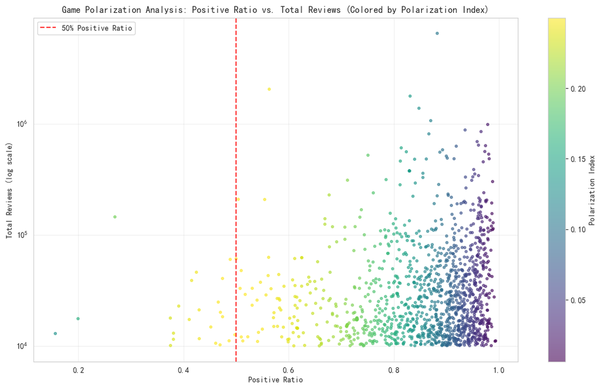

```python
# 计算总评价数和好评率
df['total_reviews'] = df['positive'] + df['negative']
df['positive_ratio'] = df['positive'] / df['total_reviews'].replace(0, np.nan) # 避免除以0

# 计算“两极分化指数”
# 公式: (positive * negative) / (total_reviews)^2
df['polarization_index'] = (df['positive'] * df['negative']) / (df['total_reviews']**2)

# 处理 total_reviews 为0或NaN的情况
df['polarization_index'] = df['polarization_index'].replace([np.inf, -np.inf], np.nan)
# 首先过滤掉评价数太少的游戏，比如少于100条评价，这些游戏没有统计意义。
df_sufficient_reviews = df[df['total_reviews'] >= 10000].copy()

# 按“两极分化指数”降序排列，找到最两极分化的游戏
most_polarizing_games = df_sufficient_reviews.nlargest(20, 'polarization_index')[
    ['name', 'positive', 'negative', 'total_reviews', 'positive_ratio', 'polarization_index', 'genres', 'developers']
]

# 显示结果
print("Top 20 Most Polarizing Games (by polarization index):")
display(most_polarizing_games)




plt.figure(figsize=(14, 8))

# 绘制散点图，点的大小代表总评价数，颜色代表两极分化指数
scatter = plt.scatter(
    x=df_sufficient_reviews['positive_ratio'],
    y=df_sufficient_reviews['total_reviews'],
    c=df_sufficient_reviews['polarization_index'],
    s=10, # 点的大小
    alpha=0.6,
    cmap='viridis' # 颜色映射，黄色越高，紫色越低
)

plt.colorbar(scatter, label='Polarization Index')
plt.xlabel('Positive Ratio')
plt.ylabel('Total Reviews (log scale)')
plt.yscale('log') # 因为总评价数差异巨大，使用对数坐标
plt.title('Game Polarization Analysis: Positive Ratio vs. Total Reviews (Colored by Polarization Index)')
plt.axvline(x=0.5, color='red', linestyle='--', alpha=0.8, label='50% Positive Ratio') # 标记中间线
plt.legend()
plt.grid(True, alpha=0.3)
plt.show()
```

## 6. 👥 Player Behavior Analysis

- Playtime analysis
  - High sitckness(residual) games analysis
  - High playtime game characteristics
- Player review analysis
  - Positive/negative review study
  - Polarizing review games analysis
- Concurrent users and game popularity relationship